# Cerag Oguztuzun: Lab 04 for 431

Cerag Oguztuzun

2021-10-09

## Setup

```r
library(equatiomatic)
library(knitr)
library(palmerpenguins)
library(janitor)
library(broom)
library(tidyverse)
```

# Question 1

- **URL of headline:** https://bit.ly/3aeiUOl
- **Info:**“This Popular Supplement Could Increase Your Risk of Heart Problems” by Krissy Gasbarre published in MSN Lifestyle website’s ‘Eat This, Not That!’ section.
- **Citation:** This popular supplement could increase your risk of heart problems. [Online]. Available: https://www.msn.com/en-us/health/medical/this-popular-supplement-could-increase-your-risk-of-heart-problems/ar-AAPeJWu. [Accessed: 07-Oct-2021].

# Question 2

- **URL of paper:** https://bit.ly/3aiySqw
- **Info:** “Effect of Long-Term Marine Omega-3 Fatty Acids Supplementation on the Risk of Atrial Fibrillation in Randomized Controlled Trials of Cardiovascular Outcomes: A Systematic Review and Meta-Analysis” by authors Baris Gencer, Luc Djousse, Omar T Al-Ramady, Nancy R Cook, JoAnn E Manson, Christine M Albert published in journay ‘Circulation’ in October 6, 2021.
- **Citation:** Gencer B, Djousse L, Al-Ramady OT, Cook NR, Manson JE, Albert CM. Effect of Long-Term Marine Omega-3 Fatty Acids Supplementation on the Risk of Atrial Fibrillation in Randomized Controlled Trials of Cardiovascular Outcomes: A Systematic Review and Meta-Analysis. Circulation. 2021 Oct 6. doi: 10.1161/CIRCULATIONAHA.121.055654. Epub ahead of print. PMID: 34612056.

# Question 3

Regarding the title “This Popular Supplement Could Increase Your Risk of Heart Problems”, my initial opinion is that It might be true. Because there are lots of supplements nowadays which can easily be replaced by correct diet choices. It is likely that a supplement can have side effects on human body, given that all it takes is breaking the balance of the human body. I say the odds of this being true is 3 in 4. The **initial gut feeling** is set to 3/4, which is less than 1 indicating I am less likely to believe in the study according to Jeff Leek.

Pr( the title is true ) = (3/4) / ( 1 + 3/4 ) = 0.42857142857

# Question 4

## Characteristic 1

- **“Was the study a clinical study in humans?”**

Yes, from the first sentence of the abstract: “Some, but not all, large-scale randomized controlled trials (RCTs) investigating the effects of marine omega-3 fatty acids supplementation on cardiovascular outcomes have reported increased risks of atrial fibrillation (AF).”, It can be understood that the study data were derived from randomized controlled trials on patients. RCTs are clinical trials that compare the effects of treatments.

## Characteristic 2

- **Was the outcome of the study something directly related to human health like longer life or less disease? Was the outcome something you care about, such as living longer or feeling better?**

Yes, the outcome of the study was the association of marine omega-3 supplementation and the risk of atrial fibrillation. In the abstract, It states: “In RCTs examining cardiovascular outcomes, marine omega-3 supplementation was associated with an increased risk of AF.”. People with atrial fibrillation face coronary artery diseases and heart attacks which affect their life span and quality of living. This study reveals a factor that affects artery diseases so that It can be reduced. Hence, the outcome of the study is directly related to human health.

## Characteristic 3

- **Was the study a randomized, controlled trial (RCT)?**

Yes, the abstract states: “RCTs of cardiovascular outcomes of marine omega-3 fatty acids that reported results for AF, either as pre-specified outcome were included.”

## Characteristic 4

- **Was it a large study — at least hundreds of patients?**

Yes, the abstract states that a “minimum sample size of 500 patients” was included in the study, hence It is a large study.

## Characteristic 5

- **Did the treatment have a major impact on the outcome?**

No, the paper only states the association between marine omega-3 supplementation and the risk of atrial fibrillation without proposing a treatment. Also in the abstract, It is stated that: “In metaregression, the hazard ratio for atrial fibrillation increased per 1 gr increase of omega-3 fatty acids dosage” which shows that they have found an association, however this does not have a major impact on cases of atrial fibrillation.

## Characteristic 6

- **Did predictions hold up in at least two separate groups of people?**

Yes, the study looked at 81,210 patients from 7 trials.

# Question 5

Given that I have the ‘initial gut feeling’ from Question 3 which is 3/4, I will calculate the ‘support for the headline’ by multiplying by 2 for every characteristic met and multiplying by 1/2 for every characteristic unmet regarding Jeff Leek.

support for headline = 2 * 2 * 2 * 2 * (1/2) * 2 = 16 final opinion on title = (initial gut feeling) * (support for headline) = 3/4 * 16 = 12

# Question 6

I filtered the penguins dataset, so that there aren’t any rows with missing data. The resulting dataset has 333 rows.

```r
#cleaning penguin data
penguins <- penguins %>%
    filter(complete.cases(.))
penguins
```

```
# A tibble: 333 x 8
   species island    bill_length_mm bill_depth_mm flipper_length_mm
   <fct>   <fct>              <dbl>         <dbl>             <int>
 1 Adelie  Torgersen           39.1          18.7               181
 2 Adelie  Torgersen           39.5          17.4               186
 3 Adelie  Torgersen           40.3          18                 195
 4 Adelie  Torgersen           36.7          19.3               193
 5 Adelie  Torgersen           39.3          20.6               190
 6 Adelie  Torgersen           38.9          17.8               181
 7 Adelie  Torgersen           39.2          19.6               195
 8 Adelie  Torgersen           41.1          17.6               182
 9 Adelie  Torgersen           38.6          21.2               191
10 Adelie  Torgersen           34.6          21.1               198
# ... with 323 more rows, and 3 more variables: body_mass_g <int>,
#   sex <fct>, year <int>
```

In this code chunk, a seed is set for ensuring each time the code is run the same randomized sets of data are formed for training and test data. I formed two tibbles named `pen_train` which consists of 200 of the penguins data which is done using the `sample_n` function, the `pen_test` tibble consists of the remaining 133 rows of the penguins data. First, a column for IDs is added to the penguins dataset to identify the selected rows. To create the `pen_test` set, the `anti_join` function is used where the parameters are the dataset where I want to do the join on and the column of the dataset in the first parameter to do the antijoin on. This selects the IDs of rows in the penguins dataset which is not the IDs chosen for the train set.

```r
penguins <- penguins %>% dplyr::mutate(penguins, ID = row_number())
penguins
```

```
# A tibble: 333 x 9
   species island    bill_length_mm bill_depth_mm flipper_length_mm
   <fct>   <fct>              <dbl>         <dbl>             <int>
 1 Adelie  Torgersen           39.1          18.7               181
 2 Adelie  Torgersen           39.5          17.4               186
 3 Adelie  Torgersen           40.3          18                 195
 4 Adelie  Torgersen           36.7          19.3               193
 5 Adelie  Torgersen           39.3          20.6               190
 6 Adelie  Torgersen           38.9          17.8               181
 7 Adelie  Torgersen           39.2          19.6               195
 8 Adelie  Torgersen           41.1          17.6               182
 9 Adelie  Torgersen           38.6          21.2               191
10 Adelie  Torgersen           34.6          21.1               198
# ... with 323 more rows, and 4 more variables: body_mass_g <int>,
#   sex <fct>, year <int>, ID <int>
```

```r
set.seed(4312021)

pen_train <- penguins %>% sample_n(200)
pen_test <- penguins %>% anti_join( pen_train, by = 'ID')
cat("Number of rows of train set:", nrow(pen_train),"\n")
```

```
Number of rows of train set: 200
```

```r
cat("Number of rows of test set:", nrow(pen_test),"\n")
```

```
Number of rows of test set: 133
```

# Question 7

A linear model called `model1` is created using the relationship between body mass in grams and bill length in millimeters. The `pen_train` data is used to establish the model.

```r
model1 <- lm(body_mass_g ~ bill_length_mm, data = pen_train)
```

The equation of the linear model that shows the relationship between body mass in grams and bill length in millimeters is displayed. This equation will also be placed in the ‘Association of Bill Lengths and Body Masses of Palmer Penguins’ plot.

```r
extract_eq(model1, use_coefs = TRUE, coef_digits = 2)
```

$$\operatorname{\widehat{body\_mass\_g}} = 458.76 + 85.33(\operatorname{bill\_length\_mm})$$

Regarding the relationship between `bill_length_mm` and `body_mass_g`, the slope of the linear model is positive which tells the correlation should be positive. Also, the Pearson r value should be about 0.5 which does not indicate a very tight and strong correlation but does not either indicate a weak correlation between `bill_length_mm` and `body_mass_g`. Additionally, a curve in the loess smooth is seen, which is caused by the 2 points between 55 and 60 in the x-axis (bill lengths) and 3500 and 4000 in the y-axis (body masses), which weigh the loess smooth down in -y-direction, having low body masses.

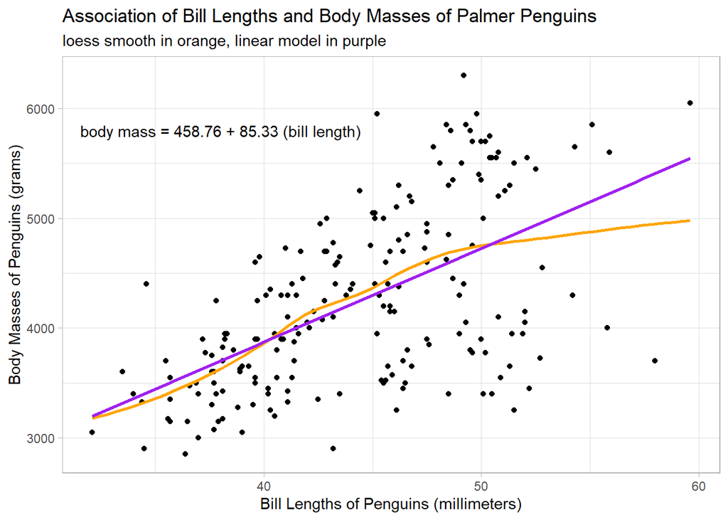

```r
ggplot(data = pen_train, aes(x = bill_length_mm, y = body_mass_g)) +
  geom_point() +
  geom_smooth(method = "loess", col = "orange",
              se = FALSE, formula = y ~ x) +
  geom_smooth(method = "lm", col = "purple",
              se = FALSE, formula = y ~ x) +
  theme_light() +
  labs(title = "Association of Bill Lengths and Body Masses of Palmer Penguins",
       x = "Bill Lengths of Penguins (millimeters)",
       y = "Body Masses of Penguins (grams)",
       subtitle = "loess smooth in orange, linear model in purple") +
  annotate("text", x = 38, y = 5800, label = "body mass = 458.76 + 85.33 (bill length)")
```

# Question 8

```r
pen_test_fitted <- augment(model1, newdata = pen_test)
pen_test_fitted %>% nrow()
```

```
[1] 133
```

```r
mosaic::favstats(~ abs(.resid), data = pen_test_fitted) %>%
        select(n, min, median, max, mean, sd) %>% kable(digits = 2)
```

|  | n | min | median | max | mean | sd |
| --- | --- | --- | --- | --- | --- | --- |
|  | 133 | 2.16 | 467.09 | 1760.91 | 516.7 | 364.65 |

```r
sqrt(mean(pen_test_fitted$.resid^2)) %>% kable(col.names = 'r.squared')
```

| r.squared |
| --- |
| 631.6267 |